# Trabajo Final

Pilar Piñeiro

19 de junio de 2016

# INTRODUCCIÓN

## Motivo

El linfoma difuso de células B (DLBCL o DLBL) es un tipo de cáncer de las células B responsables de la producción de anticuerpos. Este es clínicamente heterogéneo: 40% de los pacientes responden bien a la terapia actual mientras que el resto sucumbe a la enfermedad.

Este estudio propone que esta variabilidad refleja una heterogeneidad no reconocida en los tumores. Usando microarrays de DNA, se ha observado la expresion de genes en las células B. Aquí se muestra que existe una diversidad en la expresión génica entre los tumores de los pacientes de DLBCL. Se identificaron dos formas moleculares distintas de DLBCL. Un tipo expresaba genes característicos de células B de centro germinal (**linfoma de células B semejantes a las del centro germinal (GCB)**); el otro tipo expresaba genes inducidos normalmente (**linfoma de células semejantes a la célula B activada (ABC)**). Los pacientes con GCB mostraban una mejoría significativa frente a los que tenían ABC.

De esta forma, la clasificación de los tumores en base a la expresión de genes puede identificar subtipos de cáncer previamente no identificados.

## Objetivo

Vamos a centrarnos en la predicción de clasificación del tumor en función de la expresión de ciertos genes.

Los genes que nos interesa encontrar y usar para nuestra predicción son los que describan mejor esa clasificacíón. (Los que marquen la diferencia entre los dos subtipos del tumor.)

## Metodología

Los datos del estudio comprenden 47 muestras con 4027 genes observados para cada muestra según el nivel de expresión, y el subtipo o clase de cada muestra: *germinal*, *activated*.

Cargaremos los datos y generaremos un modelo de clasificación de subtipo de DLBCL haciendo uso de modelos de regresión logística, redes neuronales (ANN), máquinas de soporte vectorial (SVM) y árboles de decisión (DT). Usaremos el área bajo la curva ROC como métrica de evaluación del rendimiento del modelo y luego compararemos los diferentes modelos para ver cuál clasifica mejor.

# Datos

Cargamos los datos que estan en formato *arff*. Para no tener problemas en el futuro con el código, convertimos “NA” a 0.

Visualizamos el número de datos de cada clase:

```r
library(foreign)

data<-read.arff("/Users/pilarpineiro/Google\ Drive/3ro/Segundo\ Cuatri/Mineria\ Datos/R/TrabajoFinal/DLBCL-Stanford/DLBCL-Stanford.arff")
data[is.na(data)] <- 0
summary(data$Class)
```

```
## activated  germinal
##        23        24
```

# Selección de variables

## Filtrado y Wrapper

Tenemos una gran cantidad de atributos (genes), y nos interesa quedarnos con los que mejor describan la clase a la que pertenece cada muestra. Para ello, vamos a filtrar los datos.

Probamos dos filtros distintos y un wrapper para ver con qué atributos quedarnos para seguir trabajando en los modelos de clasificación. La función *FilterFeatures* aplica el filtro deseado a los datos y devuelve una fórmula para usar en los modelos.

### Aplicamos Filter: chi squared e information gain

```r
library(FSelector)

FilterFeatures<-function(model,data,funct){
  weights<-funct(model,data)
  subset<-cutoff.k(weights,4)
  f<-as.simple.formula(subset,"Class")
  return(f)
}

filtvbles<-FilterFeatures(Class~.,data,chi.squared)
start.time.filter <- Sys.time()
filtvbles2<-FilterFeatures(Class~.,data,information.gain)
end.time.filter<- Sys.time()
time.taken.filter<-end.time.filter - start.time.filter
```

```
## Class ~ GENE3261X + GENE3327X + GENE3330X + GENE3328X
## <environment: 0x7fbb94cdeaa8>
```

```
## Class ~ GENE3261X + GENE3327X + GENE3330X + GENE3328X
## <environment: 0x7fbb93596840>
```

Como ambos filtros devuelven los mismos genes, vamos a comparar el resultado obtenido con el de un método wrapper.

### Aplicamos Wrapper: forward search

Para aplicar el Wrapper necesitamos una función de evaluación. Usaremos la validación cruzada con regresión logística (porque no necesita ajuste de parámetros) con métrica de AUC.

```r
start.time.wrapper <- Sys.time()
subset<-forward.search(names(data)[-4027],CrValLRW)
end.time.wrapper<- Sys.time()
time.taken.wrapper<-end.time.wrapper - start.time.wrapper

fw<-as.simple.formula(subset,"Class")
print(fw)
```

```
## Class ~ GENE4006X + GENE3330X
## <environment: 0x7fbb931bc158>
```

El método Wrapper devuelve una fórmula distinta, así que vamos a comparar con un modelo de predicción qué combinación de variables es mejor. Probamos con Decision Trees, ya que al ser uno de los métodos menos buenos podemos apreciar mejor la diferencia de funcionamiento entre las variables.

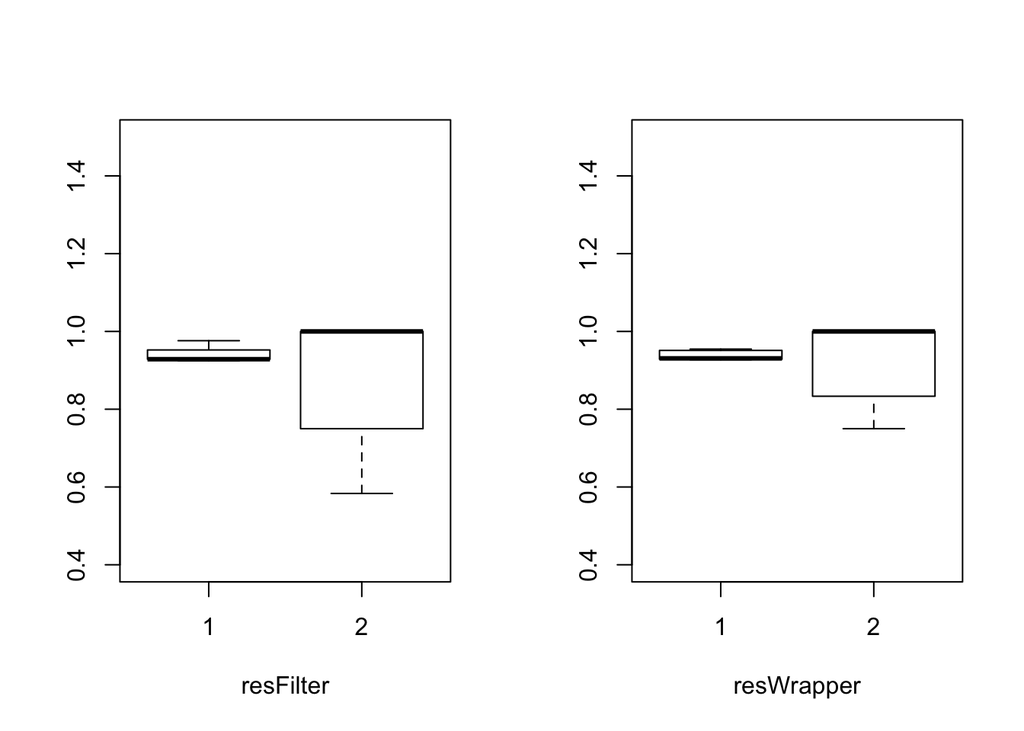

```r
resWrapper<-ValCrDT_WRAPPER(data,0.07)

resFilter<-ValCrDT(data,0.07)

par(mfrow=c(1,2))
boxplot(cbind(unlist(resFilter[1,]),unlist(resFilter[2,])),xlab="resFilter",ylim=c(0.4,1.5))
boxplot(cbind(unlist(resWrapper[1,]),unlist(resWrapper[2,])),xlab="resWrapper",ylim=c(0.4,1.5))
```

Los resultados son parecidos, pero el coste computacional de Filter es mucho menor. Veamos los tiempos de ejecución de cada algoritmo:

```
## [1] "Tiempo Filter:"
```

```
## Time difference of 14.57019 secs
```

```
## [1] "Tiempo Wrapper:"
```

```
## Time difference of 20.75167 hours
```

En general los métodos Wrapper suelen ser más exactos, ya que se guían por el “feedback” de la evaluación con cada combinación de las variables, pero la diferencia existente entre los resultados de Filter y Wrapper no es demasiado grande y conviene un menor tiempo de cómputo.

En deifnitiva, usaremos los resultados del método Filter :

```
## Class ~ GENE3261X + GENE3327X + GENE3330X + GENE3328X
## <environment: 0x7fbb94cdeaa8>
```

Tenemos 4 variables. Los atributos son variables numéricas, mientras que la clase es una variable categórica. Vamos a observar cómo de relacionadas están. Si nuestra muestra sigue una distribucion normal, aplicamos T.test. Para ello, la muestra tiene que tener suficientes individuos para ser representativa de la población en estudio. (La N ha de ser suficientemente grande).

```r
gen1<-t.test(GENE3261X~Class,data)
gen2<-t.test(GENE3327X~Class,data)
gen3<-t.test(GENE3330X~Class,data)
gen4<-t.test(GENE3328X~Class,data)
```

```r
gen1$p.value
```

```
## [1] 3.993653e-09
```

```r
gen2$p.value
```

```
## [1] 2.952995e-11
```

```r
gen3$p.value
```

```
## [1] 6.884808e-10
```

```r
gen4$p.value
```

```
## [1] 7.465685e-10
```

Vemos que todos los valores de p son muy bajos: se rechaza la hipótesis nula en T test: se considera entonces que las variables son dependientes es decir, que las 4 variables describen bien la clase.

# Función de estimación

Para estimar los modelos, podemos usar Repeated Holdout o Cross Validation. Vamos a observar los resultados con ambos métodos:

### Repeated Holdout

Este método requiere repetir la función Holdout un número elevado de veces para conseguir un resultado lo más realista posible. Vamos a probar si repitiendolo 150 veces nos devuelve el mismo resultado que si lo aplicamos 30 veces pero repitiendo en el Holdout el AUC 5 veces, y luego usando la media de esos 5 resultados:

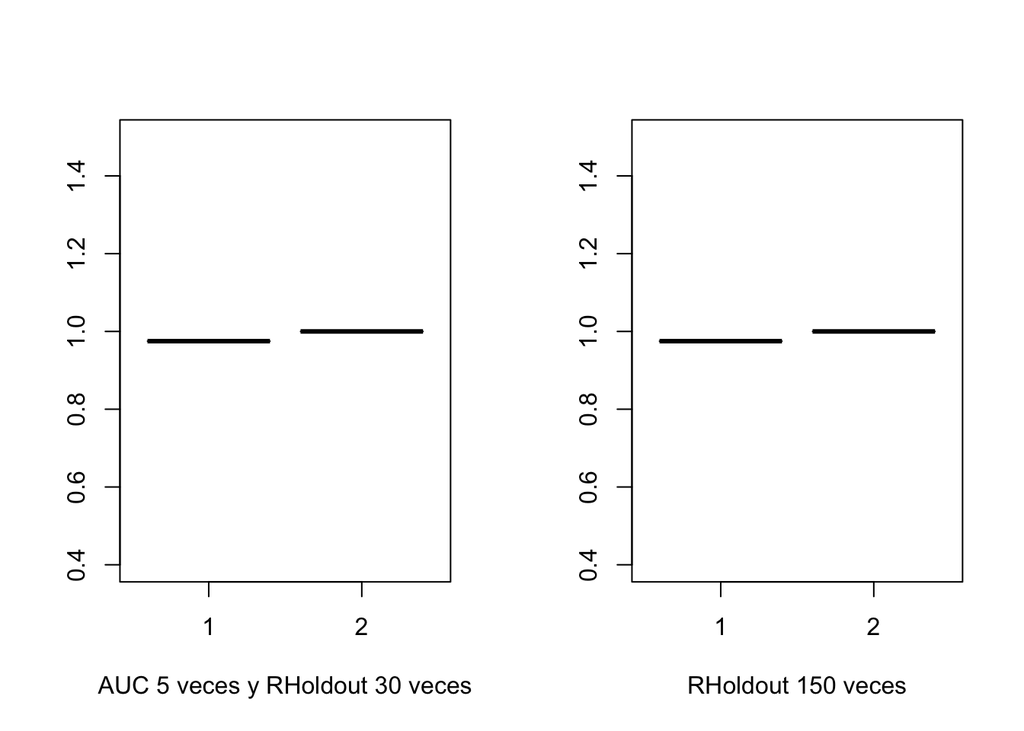

```r
res_5AUC<-RHoldOutRN_5AUC(data,30,2/3,5,100,4e-1)
res_150<-RHoldOutRN(data,150,2/3,5,100,4e-1)

print(mean(res_5AUC[1,]))
print(mean(res_5AUC[2,]))
print(mean(res_150[1,]))
print(mean(res_150[2,]))

par(mfrow=c(1,2))
boxplot(cbind(unlist(res_5AUC[1,]),unlist(res_5AUC[2,])),xlab="AUC 5 veces y RHoldout 30 veces",ylim=c(0.4,1.5))
boxplot(cbind(unlist(res_150[1,]),unlist(res_150[2,])),xlab="RHoldout 150 veces",ylim=c(0.4,1.5))
```

[output not shown]

Efectivamente, el resultado es el mismo.

### Comparación

Comparemos los resultados con Repeated Holdout y con Cross Validation utilizando Redes Neuronales y evaluación con métrica AUC.

```r
start.time.RHold<- Sys.time()
resRHoldout<-RHoldOutRN(data,30,2/3,5,1100,5e-4)
end.time.RHold<- Sys.time()
time.taken.RHold<-end.time.RHold - start.time.RHold

start.time.CV<- Sys.time()
resValCr<-ValCrRN(data,5,1100,5e-4)
end.time.CV<- Sys.time()
time.taken.CV<-end.time.CV - start.time.CV
```

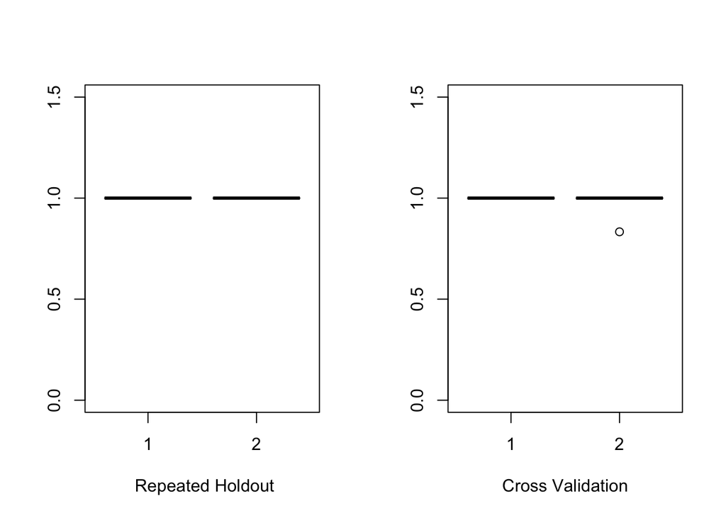

```r
par(mfrow=c(1,2))
boxplot(cbind(unlist(resRHoldout[1,]),unlist(resRHoldout[2,])),xlab=" Repeated Holdout",ylim=c(0,1.5))
boxplot(cbind(unlist(resValCr[1,]),unlist(resValCr[2,])),xlab="Cross Validation",ylim=c(0,1.5))
```

Los resultados son similares.Redes Neuronales es un método bueno, y estamos usando variables que describen bien la variable Class: por eso no se ve gran diferencia.

El tiempo de cómputo usando cada uno es el siguiente:

```
## [1] "Repeated Holdout:"
```

```
## Time difference of 2.982891 secs
```

```
## [1] "Cross Validation:"
```

```
## Time difference of 1.05154 secs
```

# Comparación de métodos

Vamos a estimar modelos de regresión logística, ANN, SVM y árboles de decisión. Vamos a comparar los resultados en base al AUC en generalización. A diferencia del ACC, el AUC nos permite evaluar independientemente de donde esté el umbral (clases desbalanceadas).

Probando con los modelos debemos tener en cuenta:

- El ajuste de parámetros en una red neuronal artificial es crítico para la obtención de buenos resultados en generalización. Para ello escogemos la mejor de las diferentes tipos de arquitecturas que produce mejores resultados en cuanto al AUC del clasificador. **Decay**: procedimiento para evitar el problema típico en ajuste de este tipo de modelos que es el sobreentrenamiento. La “caída” del error de entrenamiento provoca caída de capacidad de generalización.
- En el caso de SVM, probamos diferentes valores para cost y gamma.
- Para Decision Trees hemos ido variando la profundidad del árbol. Tuvimos en cuenta que aumentar mucho la profundidad puede provocar overfitting.

Vamos a compararlos entre sí:

```r
#Redes Neuronales
rescrval<-ValCrRN(data,5,1100,5e-4)
mean(rescrval[2])

#Regresion Logistica
reglogcrval<-ValCrRL(data)

#Support Vector Machine
svmcrval<-ValCrSVM(data,1900,0.7,TRUE)

#Decision Trees
DTcrval<-ValCrDT(data,0.06)
```

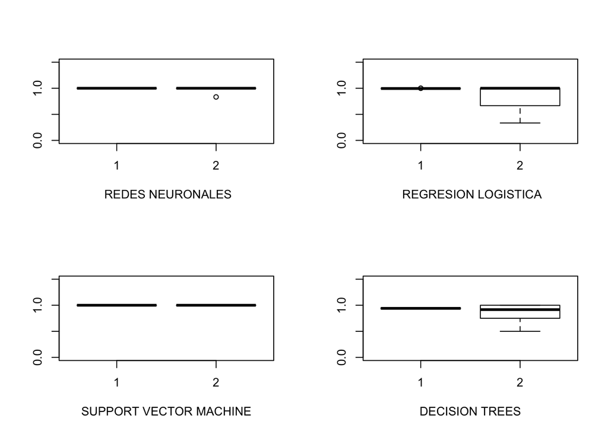

```r
par(mfrow=c(2,2))
boxplot(cbind(unlist(rescrval[1,]),unlist(rescrval[2,])),xlab=" REDES NEURONALES",ylim=c(0,1.5))
boxplot(cbind(unlist(reglogcrval[1,]),unlist(reglogcrval[2,])),xlab=" REGRESION LOGISTICA",ylim=c(0,1.5))
boxplot(cbind(unlist(svmcrval[1,]),unlist(svmcrval[2,])),xlab="SUPPORT VECTOR MACHINE",ylim=c(0,1.5))
boxplot(cbind(unlist(DTcrval[1,]),unlist(DTcrval[2,])),xlab="DECISION TREES",ylim=c(0,1.5))
```

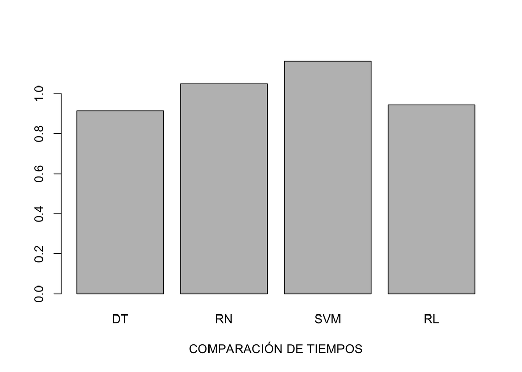

```r
par(mfrow=c(1,1))
times<-c(as.numeric(time.taken.DT),as.numeric(time.taken.RN),as.numeric(time.taken.SVM),as.numeric(time.taken.RL))
barplot(times, xlab="COMPARACIÓN DE TIEMPOS",names.arg=c("DT", "RN","SVM","RL"))
```

# Conclusión

Los dos subgrupos de DLBCL se distinguen uno del otro por la expresion diferencial de cientos de genes, y estos genes relacionan cada subgrupo a una etapa distinta de activación y diferenciación de las células B. Estas diferencias moleculares, acompañadas de diferencias clínicas entre los dos subgrupos, sugieren que estos dos subtipos de DLBCL deberían considerarse enfermedades distintas.